# COVID-19_week5_homework

Weichao Zhang

2024-06-18

## 1. Input Data

### 1.1 Read the data

Input the data from the provided URLs.

```r
library(stringr)
url_in <- "https://raw.githubusercontent.com/CSSEGISandData/COVID-19/master/csse_covid_19_data/csse_covid_19_time_series/" # This is the folder of the csv files
file_names <- c("time_series_covid19_confirmed_global.csv"        ,"time_series_covid19_deaths_global.csv", "time_series_covid19_confirmed_US.csv", "time_series_covid19_deaths_US.csv")
urls <- str_c(url_in, file_names)
```

Read in the data and create data frames.

```r
library(readr)
global_cases <- read_csv(urls[1])
global_deaths <- read_csv(urls[2])
US_cases <- read_csv(urls[3])
US_deaths <- read_csv(urls[4])
```

After looking at the data sets, I find that the date and cases/deaths are organized according to a specific country/region. I plan to analyze the trending of cases/deaths over time. Hence, I would like to create columns for the date and cases/deaths, and get rid of the Lat/Long, etc. Also, I need to put the cases and deaths into one data frame. The data sets are tidied in the following chunks.

### 1.2 Tidy the global data

Create columns for date and cases/deaths. Combine cases and deaths into one data frame.

```r
# Tidy the data sets by creating columns of date, cases/deaths
library(tidyr)
library(dplyr)
global_cases <- global_cases %>%
  pivot_longer(cols = -c('Province/State','Country/Region', Lat, Long),names_to = "date", values_to = "cases") %>%
  select(-c(Lat, Long)) # Leave out Lat and Long

global_deaths <- global_deaths %>%
  pivot_longer(cols = -c('Province/State','Country/Region', Lat, Long),names_to = "date", values_to = "deaths") %>%
  select(-c(Lat, Long))
```

Join the two data sets, and output the data set of global.

```r
library(lubridate)
global <- global_cases %>%
  full_join(global_deaths) %>%
  rename(Country_Region = 'Country/Region', Province_State = 'Province/State') %>%
  # Transform the character strings of date into the date objects
  mutate(date= mdy(date)) %>%
  # Filter out the days having no cases
  filter(cases>0)
```

Add global population to the data frame.

```r
global <- global %>%
  unite("Combined_Key", c(Province_State, Country_Region), sep=",", na.rm = TRUE, remove=FALSE)
  # The url of the csv containing the population data
  uid_lookup_url <- "https://raw.githubusercontent.com/CSSEGISandData/COVID-19/master/csse_covid_19_data/UID_ISO_FIPS_LookUp_Table.csv"
  # read in the data, and get rid of the unused.
  uid <- read_csv(uid_lookup_url) %>%
  select(-c(Lat, Long_, Combined_Key, code3, iso2, iso3, Admin2, UID, FIPS))

# Add the population data as a new column in the data set of global
global <- global %>%
  left_join(uid, by=c("Province_State", "Country_Region")) %>%
  select(Province_State, Country_Region, date, cases, deaths, Population, Combined_Key)
global # show the tidied data frame
```

```
## # A tibble: 306,827 × 7
##    Province_State Country_Region date       cases deaths Population Combined_Key
##    <chr>          <chr>          <date>     <dbl>  <dbl>      <dbl> <chr>
##  1 <NA>           Afghanistan    2020-02-24     5      0   38928341 Afghanistan
##  2 <NA>           Afghanistan    2020-02-25     5      0   38928341 Afghanistan
##  3 <NA>           Afghanistan    2020-02-26     5      0   38928341 Afghanistan
##  4 <NA>           Afghanistan    2020-02-27     5      0   38928341 Afghanistan
##  5 <NA>           Afghanistan    2020-02-28     5      0   38928341 Afghanistan
##  6 <NA>           Afghanistan    2020-02-29     5      0   38928341 Afghanistan
##  7 <NA>           Afghanistan    2020-03-01     5      0   38928341 Afghanistan
##  8 <NA>           Afghanistan    2020-03-02     5      0   38928341 Afghanistan
##  9 <NA>           Afghanistan    2020-03-03     5      0   38928341 Afghanistan
## 10 <NA>           Afghanistan    2020-03-04     5      0   38928341 Afghanistan
## # ℹ 306,817 more rows
```

### 1.3 Tidy the US data

The next step is handling the data of cases and deaths in US. The population data is included. The steps are similar.

```r
library(lubridate)
US_cases <- US_cases %>%
  pivot_longer(cols = -c(UID:Combined_Key), names_to = "date", values_to = "cases") %>%
  select(Admin2:cases) %>%
  mutate(date = mdy(date)) %>%
  select(-c(Lat, Long_))

US_deaths <- US_deaths %>%
  pivot_longer(cols = -c(UID:Population), names_to = "date", values_to = "deaths")  %>%
  select(Admin2:deaths)  %>%
  mutate(date = mdy(date)) %>%
  select(-c(Lat, Long_))

# Join the two data sets, and output the data set of US.
US <- US_cases %>%
  full_join(US_deaths) %>%
  filter(cases>0)
US # show the tidied date frame
```

```
## # A tibble: 3,474,292 × 8
##    Admin2 Province_State Country_Region Combined_Key date       cases Population
##    <chr>  <chr>          <chr>          <chr>        <date>     <dbl>      <dbl>
##  1 Autau… Alabama        US             Autauga, Al… 2020-03-24     1      55869
##  2 Autau… Alabama        US             Autauga, Al… 2020-03-25     5      55869
##  3 Autau… Alabama        US             Autauga, Al… 2020-03-26     6      55869
##  4 Autau… Alabama        US             Autauga, Al… 2020-03-27     6      55869
##  5 Autau… Alabama        US             Autauga, Al… 2020-03-28     6      55869
##  6 Autau… Alabama        US             Autauga, Al… 2020-03-29     6      55869
##  7 Autau… Alabama        US             Autauga, Al… 2020-03-30     8      55869
##  8 Autau… Alabama        US             Autauga, Al… 2020-03-31     8      55869
##  9 Autau… Alabama        US             Autauga, Al… 2020-04-01    10      55869
## 10 Autau… Alabama        US             Autauga, Al… 2020-04-02    12      55869
## # ℹ 3,474,282 more rows
## # ℹ 1 more variable: deaths <dbl>
```

## 2. Visualize data

### 2.1 Visualize the global data

Visualize the global cases and deaths over time.

```r
# Group by countries
global_by_country <- global %>%
  group_by(Country_Region, date) %>%
  select(Country_Region, date, cases, deaths, Population) %>%
  ungroup()
global_by_country
```

```
## # A tibble: 306,827 × 5
##    Country_Region date       cases deaths Population
##    <chr>          <date>     <dbl>  <dbl>      <dbl>
##  1 Afghanistan    2020-02-24     5      0   38928341
##  2 Afghanistan    2020-02-25     5      0   38928341
##  3 Afghanistan    2020-02-26     5      0   38928341
##  4 Afghanistan    2020-02-27     5      0   38928341
##  5 Afghanistan    2020-02-28     5      0   38928341
##  6 Afghanistan    2020-02-29     5      0   38928341
##  7 Afghanistan    2020-03-01     5      0   38928341
##  8 Afghanistan    2020-03-02     5      0   38928341
##  9 Afghanistan    2020-03-03     5      0   38928341
## 10 Afghanistan    2020-03-04     5      0   38928341
## # ℹ 306,817 more rows
```

```r
# Calculating the global cases/deaths by summing the countries
global_totals <- global_by_country %>%
  mutate(Population = ifelse(is.na(Population), 0, Population)) %>% # set NA to zero
  group_by(date)  %>%
  summarize(cases=sum(cases), deaths=sum(deaths), Population = sum(Population)) %>%
  ungroup()
global_totals
```

```
## # A tibble: 1,143 × 4
##    date       cases deaths Population
##    <date>     <dbl>  <dbl>      <dbl>
##  1 2020-01-22   557     17 1831310815
##  2 2020-01-23   657     18 2103147721
##  3 2020-01-24   944     26 2192446719
##  4 2020-01-25  1437     42 2259873482
##  5 2020-01-26  2120     56 2274621382
##  6 2020-01-27  2929     82 2395908634
##  7 2020-01-28  5580    131 2401123439
##  8 2020-01-29  6169    133 2421670057
##  9 2020-01-30  8237    171 3914903627
## 10 2020-01-31  9927    214 4189185919
## # ℹ 1,133 more rows
```

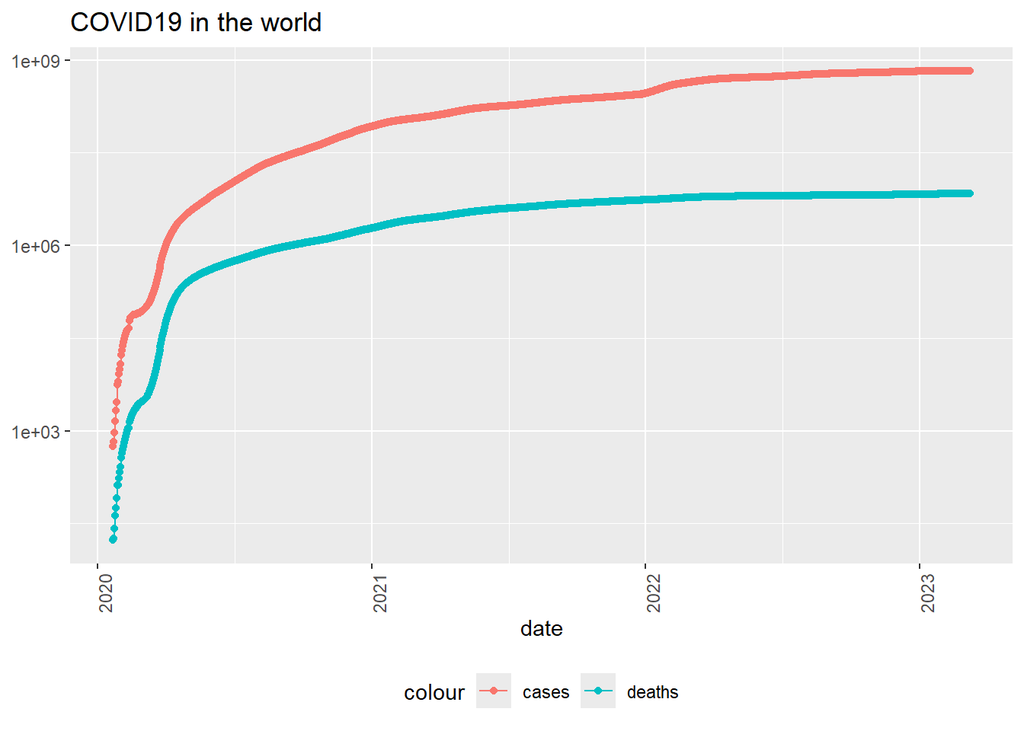

```r
# Plot a line chart to show the global cases/deaths over time
library(ggplot2)
global_totals %>%
  filter(cases>0) %>%
  ggplot(aes(x=date, y=cases)) +
  geom_line(aes(color="cases")) +
  geom_point(aes(color="cases")) +
  geom_line(aes(y=deaths, color="deaths")) +
  geom_point(aes(y=deaths, color="deaths")) +
  scale_y_log10()+
  theme(legend.position = "bottom", axis.text.x=element_text(angle=90))+
  labs(title="COVID19 in the world", y=NULL)
```

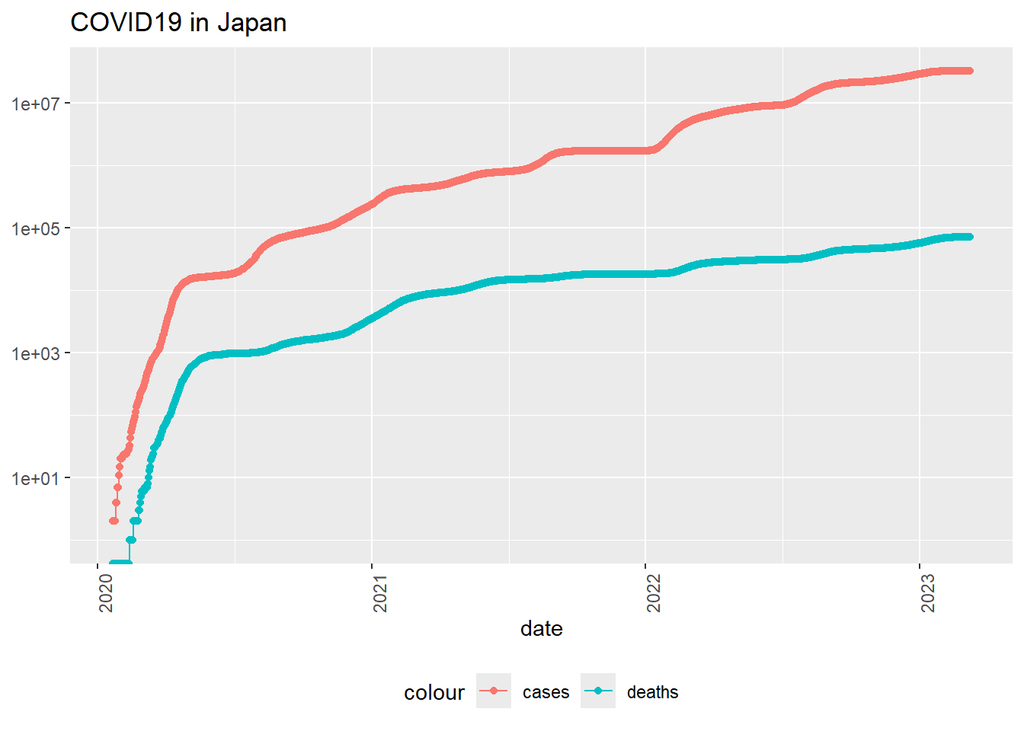

```r
# I can also look up the cases/deaths in a specific country over time
country <- "Japan"
global_by_country %>%
  filter(Country_Region == country) %>%
  filter(cases>0) %>%
  ggplot(aes(x=date, y=cases)) +
  geom_line(aes(color="cases")) +
  geom_point(aes(color="cases")) +
  geom_line(aes(y=deaths, color="deaths")) +
  geom_point(aes(y=deaths, color="deaths")) +
  scale_y_log10()+
  theme(legend.position = "bottom", axis.text.x=element_text(angle=90))+
  labs(title=str_c("COVID19 in ", country), y=NULL)
```

### 2.2 Visualize the US data

Visualize the cases and deaths in US over time.

```r
# Sum the counties within one state
US_by_state <- US %>%
  group_by(Province_State, Country_Region, date) %>%
  summarize(cases=sum(cases), deaths=sum(deaths), Population=sum(Population)) %>%
  select(Province_State, Country_Region, date, cases, deaths, Population) %>%
  ungroup()
US_by_state # The cases/deaths of counties are summed according to states
```

```
## # A tibble: 63,216 × 6
##    Province_State Country_Region date       cases deaths Population
##    <chr>          <chr>          <date>     <dbl>  <dbl>      <dbl>
##  1 Alabama        US             2020-03-11     3      0     534756
##  2 Alabama        US             2020-03-12     4      0     907665
##  3 Alabama        US             2020-03-13     8      0    1647447
##  4 Alabama        US             2020-03-14    15      0    1647447
##  5 Alabama        US             2020-03-15    28      0    2252925
##  6 Alabama        US             2020-03-16    36      0    2252925
##  7 Alabama        US             2020-03-17    51      0    2456042
##  8 Alabama        US             2020-03-18    61      0    2536020
##  9 Alabama        US             2020-03-19    88      0    3129773
## 10 Alabama        US             2020-03-20   115      0    3333968
## # ℹ 63,206 more rows
```

```r
# Calculate the total cases/deaths by summing the states within US
US_totals <- US_by_state %>%
  group_by(Country_Region, date) %>%
  summarize(cases=sum(cases), deaths=sum(deaths), Population= sum(Population))  %>%
  select(Country_Region, date, cases, deaths, Population) %>%
  ungroup()
US_totals  # The toal cases/deaths in US
```

```
## # A tibble: 1,143 × 5
##    Country_Region date       cases deaths Population
##    <chr>          <date>     <dbl>  <dbl>      <dbl>
##  1 US             2020-01-22     1      0    2252782
##  2 US             2020-01-23     1      0    2252782
##  3 US             2020-01-24     2      0    7403015
##  4 US             2020-01-25     2      0    7403015
##  5 US             2020-01-26     5      0   25103228
##  6 US             2020-01-27     5      0   25103228
##  7 US             2020-01-28     5      0   25103228
##  8 US             2020-01-29     6      0   25907135
##  9 US             2020-01-30     6      0   25907135
## 10 US             2020-01-31     8      0   27834987
## # ℹ 1,133 more rows
```

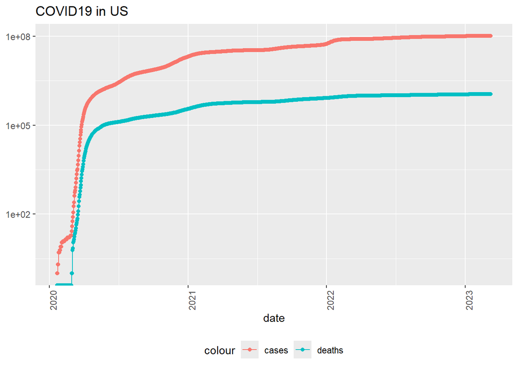

```r
# Plot a line chart to show the cases/deaths in US over time
library(ggplot2)
US_totals %>%
  filter(cases>0) %>%
  ggplot(aes(x=date, y=cases)) +
  geom_line(aes(color="cases")) +
  geom_point(aes(color="cases")) +
  geom_line(aes(y=deaths, color="deaths")) +
  geom_point(aes(y=deaths, color="deaths")) +
  scale_y_log10()+
  theme(legend.position = "bottom", axis.text.x=element_text(angle=90))+
  labs(title="COVID19 in US", y=NULL)
```

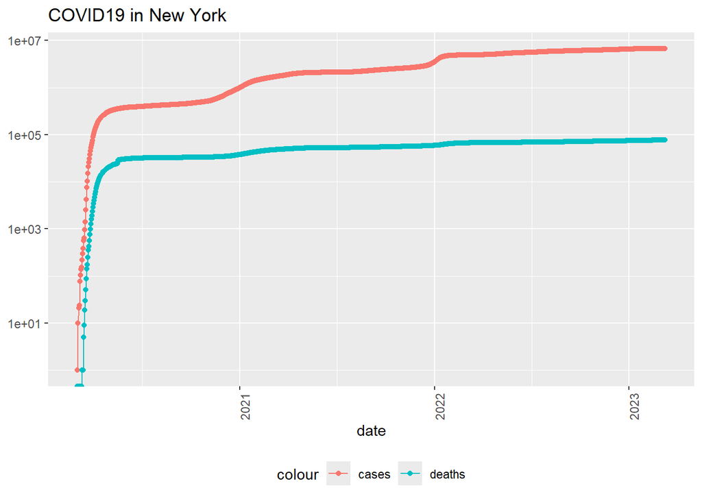

```r
# I can also look up the cases/deaths in a specific state over time
state <- "New York"
US_by_state %>%
  filter(Province_State == state) %>% filter(cases>0) %>%
  ggplot(aes(x=date, y=cases)) +
  geom_line(aes(color="cases")) +
  geom_point(aes(color="cases")) +
  geom_line(aes(y=deaths, color="deaths")) +
  geom_point(aes(y=deaths, color="deaths")) +
  scale_y_log10()+
  theme(legend.position = "bottom", axis.text.x=element_text(angle=90))+
  labs(title=str_c("COVID19 in ", state), y=NULL)
```

From the global and US cases/deaths, it can be seen that growing rate of cases/deaths seems to drop to zero. It would lead to a biased opinion that the pandemic is ending. However, we should check the new cases/deaths to determine whether COVID-19 ceases to spread. Hence, the following analyzation aims to mitigate this bias.

## 3. Data analyzation

### 3.1 Analyze the global data

Create global new cases and new deaths with respect to the dates

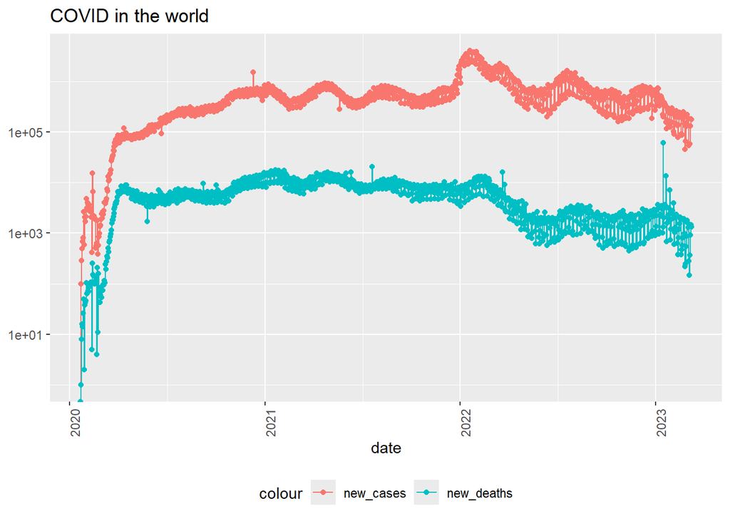

```r
global_by_country <- global_by_country %>%
  mutate(new_cases = cases - lag(cases), new_deaths=deaths-lag(deaths))
global_totals <- global_totals %>%
  mutate(new_cases = cases - lag(cases), new_deaths = deaths-lag(deaths)) %>%
  select(new_cases, new_deaths, everything()) %>%
  mutate(new_cases = ifelse(is.na(new_cases), 0, new_cases)) %>%
  mutate(new_deaths = ifelse(is.na(new_deaths), 0, new_deaths))

# Plot the global new cases/deaths over time
global_totals %>%
  ggplot(aes(x=date, y=new_cases))+
  geom_line(aes(color="new_cases")) +
  geom_point(aes(color="new_cases")) +
  geom_line(aes(y=new_deaths, color="new_deaths")) +
  geom_point(aes(y=new_deaths, color="new_deaths")) +
  scale_y_log10() +
  theme(legend.position = "bottom", axis.text.x = element_text(angle=90))+
  labs(title = "COVID in the world", y=NULL)
```

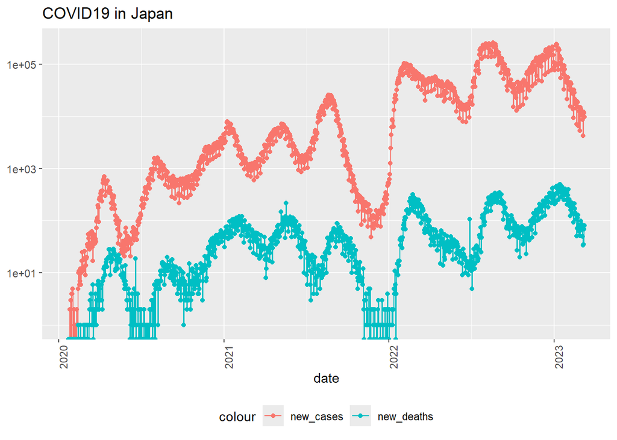

```r
# I can also check a specific country
country <- "Japan"
global_by_country %>%
  filter(Country_Region == country) %>%
  filter(cases>0) %>%
  ggplot(aes(x=date, y=new_cases)) +
  geom_line(aes(color="new_cases")) +
  geom_point(aes(color="new_cases")) +
  geom_line(aes(y=new_deaths, color="new_deaths")) +
  geom_point(aes(y=new_deaths, color="new_deaths")) +
  scale_y_log10()+
  theme(legend.position = "bottom", axis.text.x=element_text(angle=90))+
  labs(title=str_c("COVID19 in ", country), y=NULL)
```

```r
# Check the top 10 countries with least/most deaths per one thousand population
global_country_totals <- global_by_country %>%
  group_by(Country_Region) %>%
  summarize(deaths = max(deaths), cases=max(cases), Population=max(Population), cases_per_thou = 1000*cases/Population, deaths_per_thou = 1000*deaths/Population) %>%
  filter(cases>0, Population>0) %>%
  select(Country_Region, deaths, deaths_per_thou, cases, cases_per_thou, everything())
global_country_totals %>%
  slice_min(deaths_per_thou, n=10)
```

```
## # A tibble: 10 × 6
##    Country_Region deaths deaths_per_thou cases cases_per_thou Population
##    <chr>           <dbl>           <dbl> <dbl>          <dbl>      <dbl>
##  1 Holy See            0        0           29     35.8              809
##  2 Tuvalu              0        0         2828    240.             11792
##  3 Korea, North        6        0.000233     1      0.0000388   25778815
##  4 Burundi            38        0.00320  53631      4.51        11890781
##  5 Chad              194        0.0118    7679      0.467       16425859
##  6 South Sudan       138        0.0123   18368      1.64        11193729
##  7 Niger             315        0.0130    9508      0.393       24206636
##  8 Tajikistan        125        0.0131   17786      1.86         9537642
##  9 Benin             163        0.0134   27999      2.31        12123198
## 10 Tanzania          846        0.0142   42906      0.718       59734213
```

```r
global_country_totals %>%
  slice_max(deaths_per_thou, n=10)
```

```
## # A tibble: 10 × 6
##    Country_Region        deaths deaths_per_thou  cases cases_per_thou Population
##    <chr>                  <dbl>           <dbl>  <dbl>          <dbl>      <dbl>
##  1 Peru                  219539            6.66 4.49e6           136.   32971846
##  2 Bulgaria               38228            5.50 1.30e6           187.    6948445
##  3 Hungary                48762            5.05 2.20e6           227.    9660350
##  4 Bosnia and Herzegovi…  16280            4.96 4.02e5           122.    3280815
##  5 North Macedonia         9662            4.64 3.47e5           166.    2083380
##  6 Montenegro              2808            4.47 2.89e5           460.     628062
##  7 Croatia                17987            4.38 1.27e6           309.    4105268
##  8 Georgia                16971            4.25 1.83e6           458.    3989175
##  9 Czechia                42491            3.97 4.62e6           431.   10708982
## 10 Slovakia               21035            3.87 2.67e6           491.    5434712
```

By analyzing the global new cases/deaths, we can conclude that the daily new infections are above ten thousand from mid-2020 to 2023. Moreover, there are several waves of pandemics, which is more obvious from the data of Japan. From the death rates, we can see Africa countries (such as Chad and South Sudan) have lower death rates, while East European countries (such as Bulgaria and Hungary) have higher death rates. The influence by other aspects, such as the local climate, needs to be investigated further.

### 3.2 Analyze the US data

Create new cases and deaths in US with respect to the dates

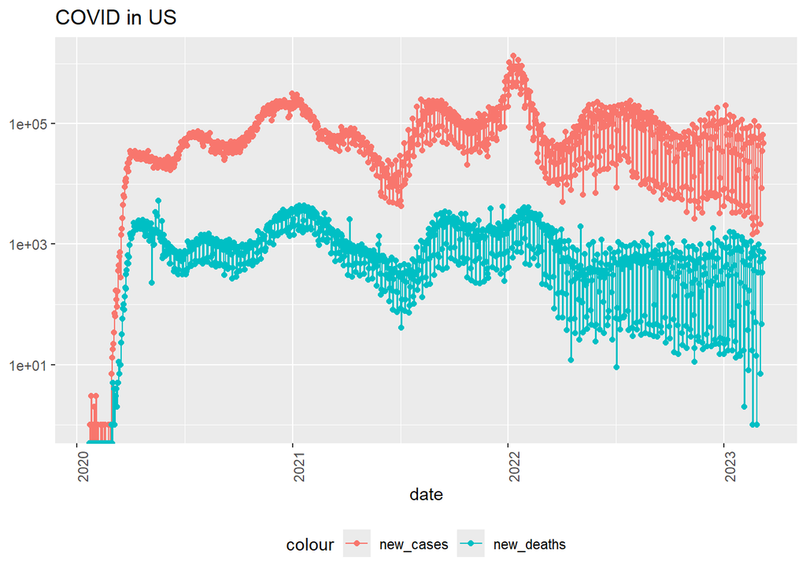

```r
US_by_state <- US_by_state %>%
  mutate(new_cases = cases - lag(cases), new_deaths=deaths-lag(deaths))
US_totals <- US_totals %>%
  mutate(new_cases = cases - lag(cases), new_deaths = deaths-lag(deaths))

# Plot the new cases and deaths in US over time
US_totals %>%
  ggplot(aes(x=date, y=new_cases))+
  geom_line(aes(color="new_cases")) +
  geom_point(aes(color="new_cases")) +
  geom_line(aes(y=new_deaths, color="new_deaths")) +
  geom_point(aes(y=new_deaths, color="new_deaths")) +
  scale_y_log10() +
  theme(legend.position = "bottom", axis.text.x = element_text(angle=90))+
  labs(title = "COVID in US", y=NULL)
```

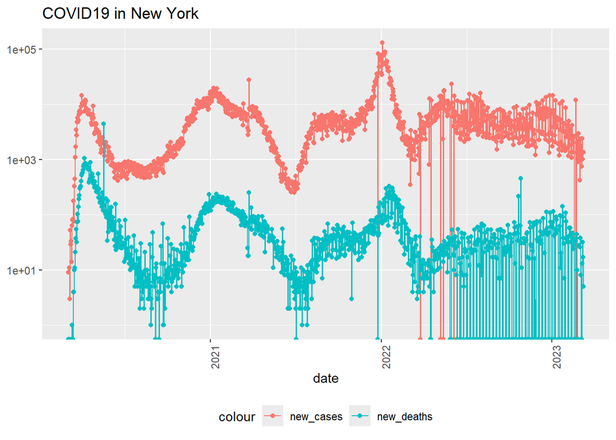

```r
# I can also check a specific state
state <- "New York"
US_by_state %>%
  filter(Province_State == state) %>% filter(cases>0) %>%
  ggplot(aes(x=date, y=new_cases)) +
  geom_line(aes(color="new_cases")) +
  geom_point(aes(color="new_cases")) +
  geom_line(aes(y=new_deaths, color="new_deaths")) +
  geom_point(aes(y=new_deaths, color="new_deaths")) +
  scale_y_log10()+
  theme(legend.position = "bottom", axis.text.x=element_text(angle=90))+
  labs(title=str_c("COVID19 in ", state), y=NULL)
```

```r
# Check the top 10 states with least/most deaths per one thousand population
US_state_totals <- US_by_state %>%
  group_by(Province_State) %>%
  summarize(deaths = max(deaths), cases=max(cases), Population=max(Population), cases_per_thou = 1000*cases/Population, deaths_per_thou = 1000*deaths/Population) %>%
  filter(cases>0, Population>0)
  US_state_totals %>%
  slice_min(deaths_per_thou, n=10) %>%
  select(deaths_per_thou, cases_per_thou, everything())
```

```
## # A tibble: 10 × 6
##    deaths_per_thou cases_per_thou Province_State        deaths  cases Population
##              <dbl>          <dbl> <chr>                  <dbl>  <dbl>      <dbl>
##  1           0.611           150. American Samoa            34 8.32e3      55641
##  2           0.744           248. Northern Mariana Isl…     41 1.37e4      55144
##  3           1.21            231. Virgin Islands           130 2.48e4     107268
##  4           1.30            269. Hawaii                  1841 3.81e5    1415872
##  5           1.49            245. Vermont                  929 1.53e5     623989
##  6           1.55            293. Puerto Rico             5823 1.10e6    3754939
##  7           1.90            391. Utah                    5298 1.09e6    2785478
##  8           2.03            252. District of Columbia    1432 1.78e5     705749
##  9           2.04            422. Alaska                  1486 3.08e5     728809
## 10           2.06            253. Washington             15683 1.93e6    7614893
```

```r
  US_state_totals %>%
  slice_max(deaths_per_thou, n=10) %>%
  select(deaths_per_thou, cases_per_thou, everything())
```

```
## # A tibble: 10 × 6
##    deaths_per_thou cases_per_thou Province_State deaths   cases Population
##              <dbl>          <dbl> <chr>           <dbl>   <dbl>      <dbl>
##  1            4.55           336. Arizona         33102 2443514    7278717
##  2            4.54           326. Oklahoma        17972 1290929    3956971
##  3            4.49           333. Mississippi     13370  990756    2976149
##  4            4.44           359. West Virginia    7960  642760    1792147
##  5            4.32           320. New Mexico       9061  670929    2096829
##  6            4.31           334. Arkansas        13020 1006883    3017804
##  7            4.29           335. Alabama         21032 1644533    4903185
##  8            4.28           368. Tennessee       29263 2515130    6829174
##  9            4.23           307. Michigan        42205 3064125    9986857
## 10            4.06           385. Kentucky        18130 1718471    4467673
```

By analyzing the US data, we can find the largest new cases/deaths are still high in the latest years, but the interval became larger, which suggests the averaged new cases/deaths dropped. The waves of pandemics are clear shown in the plot. The states with lowest death rates are the islands in the oceans, which suggests the control of pandemics benefits from isolation.

## 4. Modeling

### 4.1 Modeling the global data

Modeling the death per thousand relating to cases per thousand for the global countries by linear model

```r
mod <- lm(deaths_per_thou ~ cases_per_thou, data=global_country_totals)
global_country_totals_w_pred <- global_country_totals %>%
  mutate(pred = predict(mod)) # predicted deaths per thou
global_country_totals_w_pred
```

```
## # A tibble: 194 × 7
##    Country_Region  deaths deaths_per_thou  cases cases_per_thou Population  pred
##    <chr>            <dbl>           <dbl>  <dbl>          <dbl>      <dbl> <dbl>
##  1 Afghanistan       7896          0.203  2.09e5           5.38   38928341 0.649
##  2 Albania           3598          1.25   3.34e5         116.      2877800 1.05
##  3 Algeria           6881          0.157  2.71e5           6.19   43851043 0.651
##  4 Andorra            165          2.14   4.79e4         620.        77265 2.85
##  5 Angola            1933          0.0588 1.05e5           3.20   32866268 0.641
##  6 Antigua and Ba…    146          1.49   9.11e3          93.0       97928 0.962
##  7 Argentina       130472          2.89   1.00e7         222.     45195777 1.42
##  8 Armenia           8727          2.95   4.47e5         151.      2963234 1.17
##  9 Australia         7370          0.908  3.92e6         482.      8118000 2.36
## 10 Austria          21970          2.44   5.96e6         662.      9006400 3.00
## # ℹ 184 more rows
```

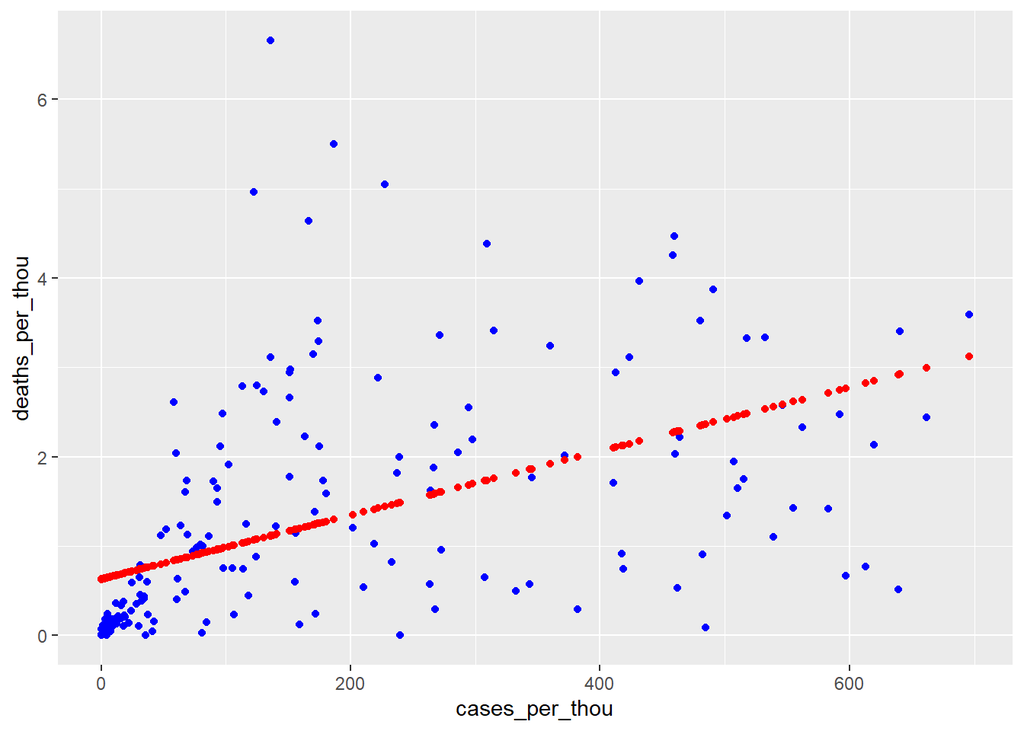

```r
global_country_totals_w_pred %>%
  ggplot()+
  geom_point(aes(x=cases_per_thou, y=deaths_per_thou), color='blue')+
  geom_point(aes(x=cases_per_thou, y=pred), color='red')
```

The result show that the cases/deaths per thousand are not linearly related when considering the global countries. As I have mentioned that African and East European countries tends to have different case/death ratios, it is suggest to assign different groups and consider multiple dimensional factors.

### 4.2 Modeling the US data

Modeling the death per thousand relating to cases per thousand for the states by linear model

```r
mod <- lm(deaths_per_thou ~ cases_per_thou, data=US_state_totals)
US_total_w_pred <- US_state_totals %>%
  mutate(pred = predict(mod)) # predicted deaths per thousand
US_total_w_pred
```

```
## # A tibble: 56 × 7
##    Province_State  deaths  cases Population cases_per_thou deaths_per_thou  pred
##    <chr>            <dbl>  <dbl>      <dbl>          <dbl>           <dbl> <dbl>
##  1 Alabama          21032 1.64e6    4903185           335.           4.29   3.39
##  2 Alaska            1486 3.08e5     728809           422.           2.04   4.28
##  3 American Samoa      34 8.32e3      55641           150.           0.611  1.50
##  4 Arizona          33102 2.44e6    7278717           336.           4.55   3.40
##  5 Arkansas         13020 1.01e6    3017804           334.           4.31   3.38
##  6 California      101159 1.21e7   39512223           307.           2.56   3.10
##  7 Colorado         14181 1.76e6    5758736           306.           2.46   3.10
##  8 Connecticut      12220 9.77e5    3565287           274.           3.43   2.77
##  9 Delaware          3324 3.31e5     973764           340.           3.41   3.44
## 10 District of Co…   1432 1.78e5     705749           252.           2.03   2.54
## # ℹ 46 more rows
```

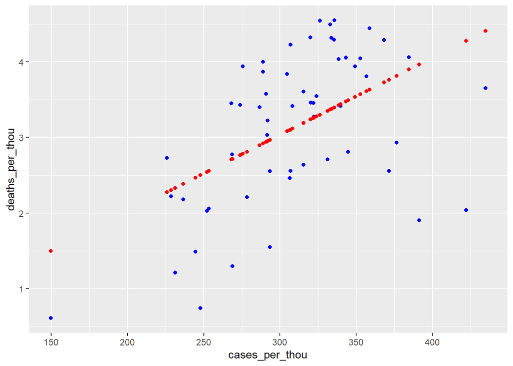

```r
US_total_w_pred %>%
  ggplot()+
  geom_point(aes(x=cases_per_thou, y=deaths_per_thou), color='blue')+
  geom_point(aes(x=cases_per_thou, y=pred), color='red')
```

Similarly, linear model is not suitable for this model fitting and prediction.

## 5. Conclusions

In this report, we analyze the global and US COVID-19 cases/deaths over time. The conclusions are made:

1. Although the total cases/deaths tends to be flatten off, daily new cases/deaths can still reach to the relatively same level as the beginning of the pandemic.
2. There are several waves of pandemics. In the latest years, the interval of new cases/deaths become wider, which suggests the averaged new cases/deaths dropped gradually.
3. African and isolated islands tend to have lower rates of deaths. Hence, it is suggest that local climate and isolation are important factors to the death rates.